# nkc2119 - Project 1

Student: Noah Chasek-Macfoy  
uni: nkc2119

## Installing necessary Packages

```r
packages.used <- c("ggplot2", "dplyr", "tibble", "tidyr",  "stringr", "tidytext", "ggridges")

# check packages that need to be installed.
packages.needed <- setdiff(packages.used, intersect(installed.packages()[,1], packages.used))

# install additional packages
if(length(packages.needed) > 0) {
  install.packages(packages.needed, dependencies = TRUE, repos = 'http://cran.us.r-project.org')
}
```

## Workspace Setup

Establishes working directory for whole document and loads Libraries used.

```r
#Note: this is a "setup" chunk.
#sets document working directory to parent folder with the .rmd
knitr::opts_knit$set(root.dir = normalizePath('../'))
# load the libraries
library(ggplot2)
library(dplyr)
library(tibble)
library(tidyr)
library(stringr)
library(tidytext)
library(ggridges)
source("../libs/multiplot.R")
```

## Read in Data

```r
# read in our data -->
spooky <- read.csv("data/spooky.csv", as.is = TRUE)
# set author column to "factor"
spooky$author <- as.factor(spooky$author)
```

## Frequency Analysis

**Motivation for Approach:** Frequency and frequency relative to other documents (i.e. tf_idf) is an intuitive way to get at what words are “characteristic” of a certain author’s texts. I use word frequency not word count so that my results are scaled relative to the total word count of each author, and therefore my results are not skewed in favor of the author with the largest sumber of words in our data set.

Cleans/Prepares Data for display

```r
# tokenize by word.
spooky_wrd <- unnest_tokens(spooky, word, text)
# This eliminates the most frequent by contexually insignificant words --> removes rows of spooky_wrd that match in column word with the stopwords list.
spooky_wrd <- anti_join(spooky_wrd, stop_words, by = "word")
# Counts number of times each author used each word.
author_words <- count(spooky_wrd, word, author)
# Counts number of times each word was used.
all_words    <- rename(count(spooky_wrd, word), all = n)
# adds column of the number of times each word appears in the corpus overall to the table
author_words <- left_join(author_words, all_words, by = "word")
#organizes data from highest frequency to lowest --> orders the tibble by the "all" column from largest to smallest
author_words <- arrange(author_words, desc(all))
#adds a colum for the frequency of a word's occurence within given author's sentences.
author_words <- ungroup(mutate(group_by(author_words, author), freqn = n/length(n)))
# alternative method to achieve line above
#count <- count(author_words, author)
#author_words <- left_join(author_words, count, by = "author")
#mutate(author_words, freqn = n/nn)
```

Creates plot of frequent words.

```r
# Top 30 within-author most frequent words for each author
most_freq <- ungroup(top_n(group_by(author_words, author),30,freqn))
# plot top 30 words by author
ggplot(most_freq) +
    geom_col(aes(reorder(word, freqn, FUN = min), freqn, fill = author)) +
    theme(legend.position = "none") +
    facet_wrap(~ author, ncol = 3, scales = "free") +
    coord_flip() +
    labs(y = "Frequency", x = NULL)
```

[output not shown]

**Comments:** This is interesting to see which words each author uses, but it does not help us predict. i.e. if we were give one of an authors most freq words from our data, we would not know how likely that word is to have come from that author

**Dis/Advanteges of approach:** My plot of the top 30 most frequent words for each author is not ordered perfectly from most to least frequent. The reason is that while “word” is an ordered factor, its levels are not equal to rows (which are word by author). Since I faceted by author the levels of factor “word” in each authors plot is not determined by the frequency fo that word within that author’s texts but the frequency of the word in the whole corpus.

## Tf-idf Analysis

Prepare data

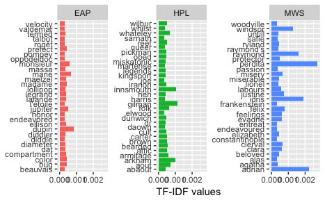

```r
author_words <- count(spooky_wrd, author, word) #redefines author_words
author_words <- rename(author_words, dtc = n) # dtc stands for document term count.
tf_idf <- bind_tf_idf(author_words, word, author, dtc) # creates td-idf data
#  within-author Top 30 highest tf_idf words for each author
most_freq <- ungroup(top_n(group_by(tf_idf, author),30,tf_idf))
# displays top 30 td_idf words within each author's sentences.
ggplot(most_freq) +
    geom_col(aes(word, tf_idf, fill = author)) +
    labs(x = NULL, y = "tf-idf") +
    theme(legend.position = "none") +
    facet_wrap(~ author, ncol = 3, scales = "free_y") + #makes flipped y-axis fixed across all facets
    coord_flip() +
    labs(y = "TF-IDF values")
ggsave("figs/top30ti_idf.png")
```

**Dis/Advanteges of approach:** It would have been nice to see some ordering by magnitude in the plots

## Tf_idf Analysis on bi-grams

**Motivation for Approach:** I use tf_idf to get at the “characteristicness” of words. Bigrams give use more context andinformation about the what is in the text. It makes sense to combine bigram and tf_idf to get a more contextual understanding of what is “characteristic” of each author.

Prepares and displays data on Frequency

```r
# Breaks up setences into bigram-by-author-by-row form
spooky_bigrams <- spooky %>%
  unnest_tokens(bigram, text, token = "ngrams", n = 2) %>% #breaks data into bigram-per-row from
  separate(bigram, c("word1", "word2"), sep = " ") %>% # separates each bigram into two columns named "word1" and "word2".
  filter(!word1 %in% stop_words$word,
         !word2 %in% stop_words$word) %>% # removes bigram rows where one of the words is in the stopwords list
  unite(bigram, word1, word2, sep = " ") # re-combines into one bigram column.

#creates table of the most common bigrams in each author
freq <- count(spooky_bigrams, author, bigram) %>%
  arrange(desc(n)) %>%
  group_by(author) %>%
  top_n(30) %>%
  ungroup

#plots highest count bigrams within each author
ggplot(freq) +
  geom_col(aes(bigram, n, fill = author), show.legend = FALSE) +
  labs(x = NULL, y = "Count") +
  facet_wrap(~author, ncol = 3, scales = "free_y") + #keeps flipped x-axis constant between authors
  coord_flip()
```

[output not shown]

Prepares data and displays bigram tf_idf analysis

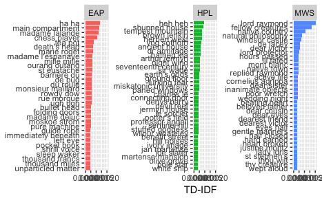

```r
# creates tf_idf analysis of my bigram data
bigram_tf_idf <- spooky_bigrams %>%
  count(author, bigram) %>%
  bind_tf_idf(bigram, author, n) %>%
  arrange(desc(tf_idf)) %>%
  mutate(bigram = factor(bigram, levels = rev(unique(bigram))))

# pulls out top 30 highet tf_idf bigrams within each author
top_30 <- bigram_tf_idf %>%
  group_by(author) %>%
  top_n(30) %>%
  ungroup
#plots highest tf_idf bigrams within each author
ggplot(top_30, aes(bigram, tf_idf, fill = author)) +
  geom_col(show.legend = FALSE) +
  labs(x = NULL, y = "TD-IDF") +
  facet_wrap(~author, ncol = 3, scales = "free_y") + #keeps flipped x-axis constant between authors
  coord_flip()
ggsave("figs/top30bigramtf_idf.png")
```

## French Analysis

Word list source: http://www.gwicks.net/dictionaries.htm

**Motivation of Approach:** Because EAP seemed to have so many french words in his highest bigram tf_idf rankings, I wondered if number of french words would be a good way to distinguish EAP from the other authors.

Prepare data and plot analysis

```r
# read in list of french words and eliminate any overlap with enlishwords. I end up with a list of words that only occur in french.
french <- read.table("data/francais.txt") #
names(french) <- "word"
english <- read.table("data/english3.txt")
names(english) <- "word"
french <- anti_join(french, english, by = "word") # a lot of common english words were in the french list, e.g. "air"
```

```
Column `word` joining factors with different levels, coercing to character vector
```

```r
#Counts how many french words are in each author's texts
spooky_fr <- inner_join(spooky_wrd, french, by = "word")
```

```
Column `word` joining character vector and factor, coercing into character vector
```

```r
count(spooky_fr, author) #meaningful result!
```

| author | n |
| --- | --- |
| EAP | 149 |
| HPL | 28 |
| MWS | 18 |

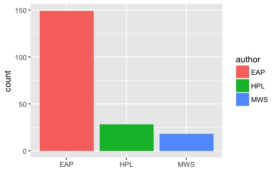

```r
#Displays above count
ggplot(spooky_fr) +
  geom_bar(aes(author, fill = author)) +
  labs(x = NULL)
ggsave("figs/frencount.png")
```

**Comment:** My suspicion was clearly born out. EAP uses signifcantly more words than the other author’s. This could be used to predict on future texts.

**Advantages/Disadvantages of method:** Will the stark findings here prove valid/predictive among a larger range of EAP? Might all the french words, even within this corpus, come from just one story and therefore prove not characteristic of EAP in general?

There may have been words in the french list that did not parse correctly because of unicode display or transformation issues. It might be worth to looking into whether there are enough words in here that need unicode transformations to try to clean any issues up.

Unlike the frequency and tf_idf analyses, this analysis is not scalled to account for the differnt total word counts of each author. Therefore this analysis is skewed toward the author with the largest word count. This problem will appear in the remainder of my analyses.

## Punctuation analysis

**Motivation of Approach:** I had a hunch, partially based on the greater sentence length variation we observed in EAP, that EAP might use more complex sentence structures and those complex sentence structures could be identified by the number of punction points used.

Prepare data and Display Analysis

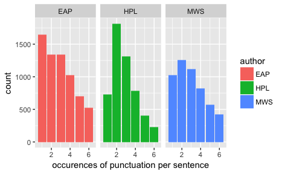

```r
#creates a sentence per row table that includes a column for punction count per sentence
spooky_punc <- mutate(spooky, pcount = str_count(text,"[[:punct:]]")) %>%
  select(id, author, pcount)
# plots frequency of different amounts of punctuation per sentence, excluding outliers
ggplot(filter(spooky_punc, pcount < 7)) +  #cuts sentences with more than 7 punctions; they are distracting outliers
    geom_bar(aes(pcount, fill = author)) +
    facet_wrap(~author, scales = "free_x") +
    labs(x = "occurences of punctuation per sentence")
ggsave("figs/punccount.png")
```

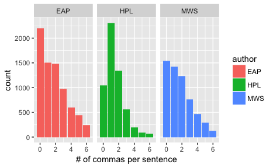

```r
# same display with commas... seems punc is mostly commas
spooky_com <- mutate(spooky, pcount = str_count(text,",")) %>%
    select(id, author, pcount)
ggplot(filter(spooky_com, pcount < 7)) +
    geom_bar(aes(pcount, fill = author)) +
    facet_wrap(~author, scales = "free_x") +
    labs(x = "# of commas per sentence")
ggsave("figs/commacount.png")
```

```r
NA
```

**Dis/Advantages:** This data has the same bias introduced by failing to scale by counts by the total word count of each author. Maybe a better approach would have been to count # of commas relative to sentence length, i.e. punctuation density, rather than a simple count. There are also some strange very high punctuation count outliers.

## Emotional Intensity

**Motivation for approach:** MWS had the most emotional language in the frequency and tf_idf analyses, so it seemed reasonable to explore whether I could measure the high levels of emotional intensity in her texts. I use magnitude of sentiment scores in “Afinn” to measure emotional intensity. Because I am not interested in the kind of sentiment but the intensity I sum negative and positive emotions separately in each sentence rather than take the difference and also sum the absolute value of sentiment scores.

Prepare data and display Analysis: Emotions by Author

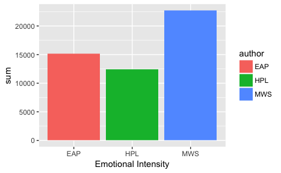

```r
# tokenize by word.
spooky_wrd <- unnest_tokens(spooky, word, text)
# This eliminates the most frequent by contexually insignificant words. Creates word by author per row table.
spooky_wrd <- anti_join(spooky_wrd, stop_words, by = "word")
#associates "afinn" scores with each word
spooky_em <- inner_join(spooky_wrd, get_sentiments("afinn"), by = "word")
# a simple look at the gross sum of emotional intensity of each author
simple <- group_by(spooky_em, author) %>%
  summarise(sum = sum(abs(score)))
ggplot(simple) +
  geom_col(aes(author, sum, fill = author)) +
  labs(x = "Emotional Intensity")
ggsave("figs/authoremotion.png")
```

Prepare data and display Analysis: Emotions by sentence by author

```r
# a look at the frequency of different emotional intensities by sentence
em <- group_by(spooky_em, id) %>%
  summarise(em = sum(abs(score)))
# adding author row to em
x <- select(spooky_em, id, author)
x <- unique(group_by(x,id))
em <- left_join(em, x, by = "id")
#creates table of negative emotions by sentence
neg <- group_by(spooky_em, id) %>%
  filter(score < 0) %>%
  summarise(neg = sum(score))
#creates table of positive emotions by sentence
pos <- group_by(spooky_em, id) %>%
  filter(score > 0) %>%
  summarise(pos = sum(score))
#combines above tables
sentence_em <- left_join(em, neg, by = "id") %>%
  left_join(pos, by = "id")
#take a look at top 100 most emotionally intense sentences. Notice how few are not MWS.
em <- head(arrange(sentence_em, desc(em)),100)
count(em, author)
```

| author | n |
| --- | --- |
| EAP | 13 |
| HPL | 2 |
| MWS | 85 |

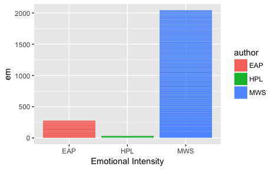

```r
ggplot(em) +
  geom_col(aes(author, em, fill = author)) +
  labs(x = "Emotional Intensity")
ggsave("figs/emotionsentences.png")
```

```r
#take a look at top 100 most emotionally negative sentences.
neg <- head(arrange(sentence_em, neg),100)
count(neg, author)
```

| author | n |
| --- | --- |
| EAP | 11 |
| HPL | 17 |
| MWS | 72 |

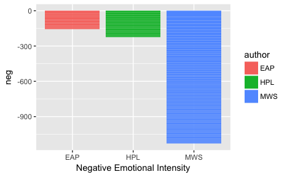

```r
ggplot(neg) +
  geom_col(aes(author, neg, fill = author)) +
  labs(x = "Negative Emotional Intensity")
ggsave("figs/negemotionsentences.png")
```

```r
#take a look at top 100 most emotionally positive sentences.
pos <- head(arrange(sentence_em, desc(pos)),100)
count(pos, author)
```

| author | n |
| --- | --- |
| EAP | 18 |
| HPL | 2 |
| MWS | 80 |

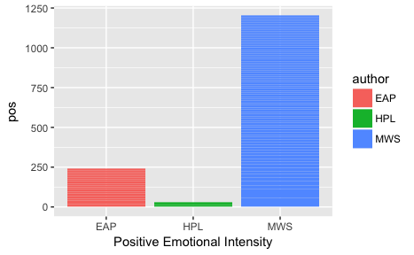

```r
ggplot(pos) +
  geom_col(aes(author, pos, fill = author)) +
  labs(x = "Positive Emotional Intensity")
ggsave("figs/posemotionsentences.png")
```

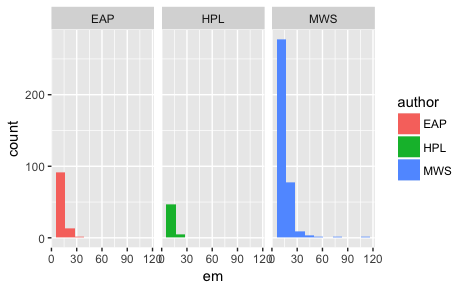

```r
# plotting as frequency
# total emptional intensity
ggplot(filter(sentence_em, em > 10), aes(x = em)) +
  geom_histogram( aes(fill = author), bins = 10 ) +
  facet_wrap(~author)
ggsave("figs/emotionfreq.png")
```

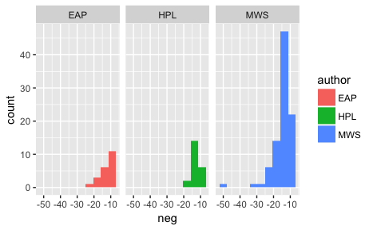

```r
#neg
ggplot(filter(sentence_em, neg < -10), aes(x = neg)) +
    geom_histogram( aes(fill = author), bins = 10 ) +
    facet_wrap(~author)
ggsave("figs/negemotionfreq.png")
```

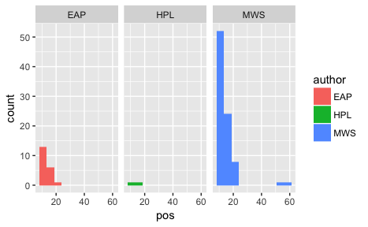

```r
#pos
ggplot(filter(sentence_em, pos > 10), aes(x = pos)) +
  geom_histogram( aes(fill = author), bins = 10 ) +
  facet_wrap(~author)
ggsave("figs/posemotionfreq.png")
```

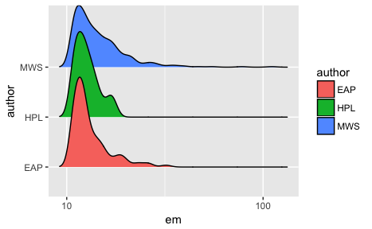

```r
# plot against each other
plot_em <- sentence_em %>%
  mutate(id = factor(id, levels = rev(unique(id)))) %>%
  arrange(desc(em)) %>%
  filter(em > 10) # get rid of area without much useful differentiation
ggplot(plot_em, aes(em, author, fill = author)) +
  geom_density_ridges() +
  scale_x_log10()
ggsave("figs/emotionfreqridges.png")
```